## 텍스트마이닝

#### 1. 패키지 설치

들어가기에 앞써 텍스트마이닝을 하기 위한 몇가지 패키지를 설치해야 된다.

wordcloud : 말 그래도 워드클라우드를 하기 위한 패키지

RColorBrewer : 여러 색을 제공해주는 팔레트 같은 패지지

KoNLP : 한국어 텍스트마이닝을 위한 패키지

library까지 해서 미리미리 준비해놓자.

```r
#install.packages("wordcloud")
#install.packages("RColorBrewer")
#install.packages("KoNLP")
library(wordcloud)
library(RColorBrewer)
library(KoNLP)
```

……………………………………………………………………………………………………………………………………………………………………………

#### 2. 데이터 준비

list.files() : 현재 작업경로에 있는 파일목록을 호출한다.

readLines(“파일이름”) : 파일을 행단위로 읽어 벡터로 저장해주는 함수

```r
list.files()
```

```
## [1] "comment.txt"               "review.txt"
## [3] "텍스트마이닝 공부 URL.txt" "텍스트마이닝 연습장.R"
## [5] "텍스트마이닝.html"         "텍스트마이닝.Rmd"
## [7] "텍스트마이닝_files"
```

```r
data <- readLines("C:/Users/madda/Documents/동아리/R문서(개인)/텍스트마이닝/comment.txt", encoding = "UTF-8")
data_all <- data
data <- head(data, 10)
```

txt파일의 데이터가 크므로 head를 이용해서 위에 10개만을 가지고 할 것이다.

wordcloud의 경우 간단하게 **wordcloud(데이터,빈도수)**로 사용할수 있다.

데이터의 빈도수가 클수록 글자의 크기는 커진다.

여러개의 데이터를 한꺼번에 다룰 수 있다. 예제를 한번 살펴보자.

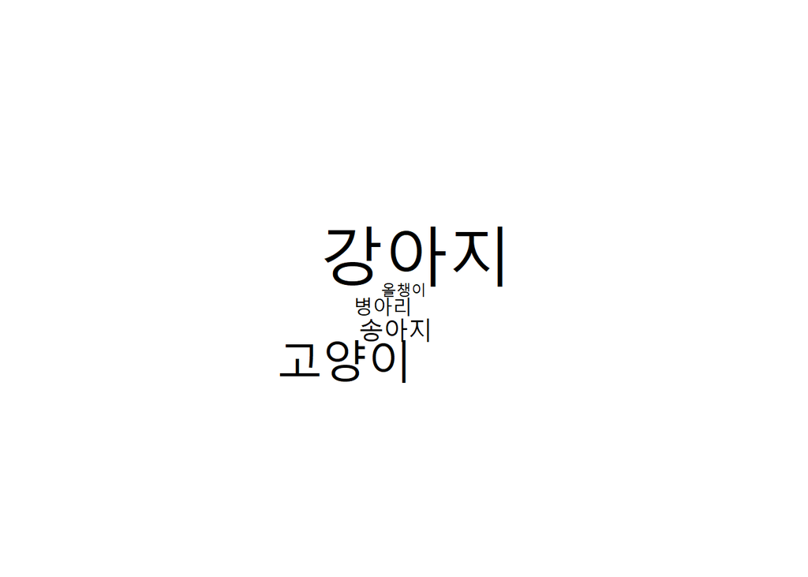

```r
word <- c("강아지","고양이","송아지","병아리","올챙이")
fre <- c(30,20,10,7,4)
wordcloud(word,fre)
```

wordcloud의 옵션을 적용을 안해서 단순하게 워드클라우드가 실행이 되었다. 아마 옵션이 없어 실행할 때마다 형태가 바뀔 것이다.

```
wordcloud 옵션

- scale : 가장 빈도가 많은 단어와 가장 빈도가 적은 단어 폰트사이의 크기차이 조정, scale = c(max,min)

- minfreq : 출력될 단어들의 최소빈도

- maxwords : 출력된 단어들의 최대빈도

- random.order = T/F (T면 랜덤, F면 빈도수가 가장 많은 단어를 중앙, 적은 순으로 외곽)

- random.color = T/F (T면 랜덤, F면 빈도순으로 색 배열)

- rot.per(90도 회전된 각도로 출력되는 단어비율)

- colors = c() (가장 작은빈도부터 큰빈도순으로 단어색 지정)

- family = "" (글씨체 지정)
```

useSejongDic() : 사전을 추가한다. (추출시, 이 함수에 등록되어 있는 단어를 기준으로 추출하게 된다.)

……………………………………………………………………………………………………………………………………………………………………………

#### 3. 명사 추출

sapply() : 리스트 대신 행렬/벡터 등의 데이터 타입으로 결과를 반환하는 함수. **sapply(data, function)**이 기본적인 형태이다. data는 적용할 데이터를 function은 데이터에 적용할 함수를 적어주면 된다.

명사를 추출하기 위해 sapply()의 function에다가 extractNoun을 넣어준다.

extractNoun : 명사를 추출하는 옵션

USE.NAMES : T/F (컬럼명을 사용하는지에 대한 여부, T/F = 사용/미사용)

```r
data_nounlist <- sapply(data,extractNoun,USE.NAMES = F)
data_nounlist <- unlist(data_nounlist)
data_nounlist <- table(data_nounlist)
data_nounlist
```

```
## data_nounlist
##              .ㅠ        ^ㅋ^ㅋ^ㅋ              ^ㅎ   서민들
##                1                1                2                1
##               10                3                5                7
##                1                1                2                1
##               값         국회의원           기름값             꼴초
##                2                1                1                1
##               나               년             담배     담배끊은지..
##                1                1                2                1
##             대비           대통령             도전             동네
##                1                1                1                1
##             된거               들               듯 등골휘게하지말고
##                1                1                1                1
##             때문               라           말보로             물가
##                1                1                1                1
##           미국은         부담되서               불             빈병
##                1                1                3                1
##   사재기하는것도             생각             세금             소득
##                1                1                1                1
##           술먹고             술집             시급             안가
##                1                2                2                1
##             얼마             연금         올리겟지   용기를가지고..
##                1                1                1                1
##             우리               원             월급             장사
##                1                1                1                1
##               적             정도               좀               줄
##                1                1                1                1
##         줄여봐ㅡ             지역             진짜             처음
##                1                1                1                1
##               천         천원씩더             커피             하나
##                1                1                1                1
##             하시               ㅠ               ㅡ
##                1                1                3
```

위에 결과값을 보면 보기 쉽게 하기 위해서 table 형태로 바꾸었다.

명사 추출할 때, 제대로 정의되지 않아서 위와 같이 나왔으므로 이상하게 나온 것이 당연하다.

……………………………………………………………………………………………………………………………………………………………………………

#### 4. 단어 등록

```r
data_noun100 <- sapply(data_all,extractNoun,USE.NAMES = F)
data_noun100 <- unlist(data_noun100)
data_noun100 <- table(data_noun100)
```

wordcloud(names(data_noun100),data_noun100)을 실행시켜보면, 단어들을 제대로 처리하지 않아서 단어가 이상하게 나오거나, 인식을 할 수 없게 나온다.

요즘 생긴 신조어라든지, 약어 등을 추가로 지정해줘야 정확하게 분석할 수 있다.

KoLNP의 mergeUserDic()을 이용햇 수동으로 단어들을 등록할 수 있다.

```r
mergeUserDic(data.frame(c("꼴초","ㅅㅂ"),"ncn"))
```

```
## 2 words were added to dic_user.txt.
```

mergeUserDIc() : 사전에 단어를 추가하는 함수.

data.frame(c(), "“)에서 c()부분은 추가할 단어를 입력,”"부분은 단어들의 품사 종류를 입력하면 된다. 위에서 ncn는 명사(비서술성 명사)를 뜻한다.

http://kkma.snu.ac.kr/documents/index.jsp?doc=postag 들어가 정확한 형태소 품사에 대한 코드를 찾아보면 도움이 된다.

위에 사전을 추가한 뒤, 처음부터 다시 코드를 실행시키면 새로운 단어들이 추가될 것이다.

……………………………………………………………………………………………………………………………………………………………………………

Filter() : 스스로 만든 함수(사용자 지정 함수)를 적용시키는 함수이다.

nchar(x) : 파라미터(단어) x의 길이를 구해주는 함수.

```r
data_noun_filter <- Filter(function(x){
    nchar(x) >= 2}, data_noun100
    )
data_noun_filter
```

```
## data_noun100
##             ^ㄱ             ^ㅋ       ^ㅋ^ㅋ^ㅋ    ^ㅋ^ㅋ^ㅋ^ㅋ
##              12             317              60              32
## ^ㅋ^ㅋ^ㅋ^ㅋ^ㅋ             ^ㅎ               1              10
##             140              46             108              68
##             100            1000           10000               2
##              45              34              17              91
##              20             200            2000            2500
##              21              28              13              12
##            2700               3              30            3000
##              12              84              14              18
##               4            4000            4500               5
##              34              19              11             104
##              50             500            5000               6
##              21              44              49              11
##               7             800               9               O
##              14              15              17              12
##            oecd            OECD              OO             OOO
##              25              52              12             139
##            가격            가스            가족            가지
##             232              11              12              31
##            각종            간접              갑              값
##              13              52             129             798
##          값인상            강간            강제              개
##              28              10              15              60
##            개념          개소리            개피              걍
##              11              17              12              48
##              거            거기            거리            걱정
##              32              16              20              47
##            건강        건강증진              것            경제
##             176              16             580              51
##            계산              곳        공공장소          공무원
##              25              23              13              28
##            공병            공사            공장            과자
##              13              14              10              18
##              구              국            국가            국민
##              13              12             104             292
##        국민건강        국민소득            국회        국회의원
##             121              21              12              43
##              군            궁금            권리            규제
```

[output cut: 214 more lines]

```
##              13              31              19              19
##            한심            할거              함              해
##              16              18              20             195
##            해결            해도            해서            해외
##              12              17             163              13
##              현            현실            호구            호주
##              10              14              18              25
##              화              확            확보            회사
##              10              18              23              42
##            회식            효과            흡연        흡연구역
##              14              13             255              37
##          흡연율          흡연자              힘              ㅠ
##              68             432              11              26
##              ㅡ            ㅡㅡ
##              78              22
```

……………………………………………………………………………………………………………………………………………………………………………

#### 6. 전처리 - 필요없는 글자 제거하기

gsub() : 바꿀 단어를 찾아서 바꿔주는 함수이다.

gsub(찾을단어, 바꿀 단어, 찾을 곳)으로 입력을 하는데 바꿀 단어 자리에 ""을 쓰면 단어가 없는 것처럼 할 수 있다.

ex) gsub(“ㅋㅋ”,"“,data_noun100)으로 하면”ㅋㅋ"라는 단어가 공백으로 처리된다.

여기서 효율적으로 처리하기 위해서 정규표현식이 필요하다.

밑의 주소로 찾아가 참조해보자.

위키 : https://ko.wikipedia.org/wiki/%EC%A0%95%EA%B7%9C_%ED%91%9C%ED%98%84%EC%8B%9D

gsub을 제대로 사용하기 위해서는 표현식을 정확히 알고 써야한다.

gsub에서 “찾을 단어”에 들어갈 문법중 “()”, “[]”은 다음과 같다.

([텍스트]) : 대괄호(=[]) 안에 묶인 글자 중 하나라도 매칭되는 것을 찾아준다.

((텍스트)) : 소괄소(=()) 안에 묶인 글자 모두가 매칭되는 것을 찾아준다.

gsub에서 “찾을 단어”에 들어갈 문법 중 “.”, “+”의 의미는 다음과 같다.

(글자).+ : “.”은 모든 글자를 의미하며 한글, 영어, 숫자 모두 해당한다. “글자”뒤에 모든 글자를 의한다. “+”는 ’하나 이상’을 의미한다.

즉, (글자).+는 “글자” 뒤에 한글자 이상으로 된 것들의 찾아준다.

^글자, 글자$ : “^”는 맨 앞을 뜻하고, “$”는 맨 뒤를 뜻한다. 따라서 맨 앞의 글자만을 바꾸거나 맨 뒤의 글자만을 고칠때는 “^글자”, “글자$”로 입력하면 된다.

```r
data_nounlist <- sapply(data,extractNoun,USE.NAMES = F)
data_nounlist <- unlist(data_nounlist)
data_nounlist
```

```
##  [1] "서민들"   "등골휘게하지말고" "국회의원"
##  [4] "들"               "연금"             "월급"
##  [7] "좀"               "줄여봐ㅡ"         "ㅡ"
## [10] "진짜"             "꼴초"             "얼마"
## [13] "사재기하는것도"   "^ㅎ"              "^ㅎ"
## [16] "담배"             "세금"             "정도"
## [19] "된거"             "담배끊은지.."     "7"
## [22] "년"               "줄"               "생각"
## [25] "용기를가지고.."   "도전"             "하시"
## [28] "라"               "부담되서"         "안가"
## [31] "장사"             "술집"             "천원씩더"
## [34] "올리겟지"         "ㅡ"               "ㅡ"
## [37] "미국은"           "시급"             "10"
## [40] "불"               "말보로"           "지역"
## [43] "동네"             "3"                "불"
## [46] "5"                "불"               "우리"
## [49] "나"               "시급"             "5"
## [52] "천"               "원"               "담배"
## [55] "값"               "커피"             "값"
## [58] "기름값"           "소득"             "대비"
## [61] "물가"             ".ㅠ"              "ㅠ"
## [64] "^ㅋ^ㅋ^ㅋ"        "술집"             "술먹고"
## [67] "빈병"             "대통령"           "하나"
## [70] "때문"             "적"               "처음"
## [73] "듯"
```

```r
data_nounlist <- gsub("(사재기).+","사재기",data_nounlist)
data_nounlist <- gsub("(용기).+","용기",data_nounlist)
data_nounlist <- gsub("(등골).+","등골",data_nounlist)
data_nounlist <- gsub("(담배값).+","담배값",data_nounlist)
data_nounlist <- gsub("(담배).+","담배",data_nounlist)
data_nounlist <- gsub("(부담).+","부담",data_nounlist)
data_nounlist <- gsub("원","천원",data_nounlist)
data_nounlist <- gsub("천","천원",data_nounlist)
data_nounlist <- gsub("(천원).+","천원",data_nounlist)
data_nounlist <- gsub("(국회).+","국회의원",data_nounlist)
data_nounlist <- gsub("(미국).+","미국",data_nounlist)
data_nounlist <- gsub("술먹고","술",data_nounlist)
data_only_noun <- data_nounlist
data_only_noun
```

```
##  [1] "서민들" "등골"      "국회의원"  "들"        "연금"
##  [6] "월급"      "좀"        "줄여봐ㅡ"  "ㅡ"        "진짜"
## [11] "꼴초"      "얼마"      "사재기"    "^ㅎ"       "^ㅎ"
## [16] "담배"      "세금"      "정도"      "된거"      "담배"
## [21] "7"         "년"        "줄"        "생각"      "용기"
## [26] "도전"      "하시"      "라"        "부담"      "안가"
## [31] "장사"      "술집"      "천원"      "올리겟지"  "ㅡ"
## [36] "ㅡ"        "미국"      "시급"      "10"        "불"
## [41] "말보로"    "지역"      "동네"      "3"         "불"
## [46] "5"         "불"        "우리"      "나"        "시급"
## [51] "5"         "천원"      "천원"      "담배"      "값"
## [56] "커피"      "값"        "기름값"    "소득"      "대비"
## [61] "물가"      ".ㅠ"       "ㅠ"        "^ㅋ^ㅋ^ㅋ" "술집"
## [66] "술"        "빈병"      "대통령"    "하나"      "때문"
## [71] "적"        "처음"      "듯"
```

일일이 수작업을 하였기 때문에 비효율적인 작업에 해당된다.

이와 같은 작업을 줄이기 위해서 단어를 선택하는 기준을 정확하게 하여야 할 것이다.

단어들 중에서 이제 필요없는 단어들에 해당되는 특수문자를 지워보도록 하자.

```
특수문자 삭제하기

1. 자음 삭제(ㅋㅋ,ㄴㄴ 등등)

gsub('[ㄱ-ㅎ]',"", 저정할 곳)

2. 모음 삭제(ㅜㅜ,ㅗㅗ 등)

gsub('(ㅜ|ㅗ)',"", 저장할 곳)

3. 숫자 삭제

gsub("\\d+","", 저장할 곳)

4. 특수문자 삭제($%^& 등등)

gsub("\\$","", 저장할 곳)
```

위에 코드들 중 \ 라는 것이 있을 것이다.(3,4번 참조)

\를 앞에 2개 붙여쓰면 사용하면 텍스트를 그대로 인식하게 된다.

```r
data_only_noun <- gsub("[ㄱ-ㅎ]","",data_only_noun)
data_only_noun <- gsub("\\d+","",data_only_noun)
data_only_noun <- gsub("^\\^+","",data_only_noun)
data_only_noun <- gsub("[ㅡ|ㅠ]","",data_only_noun)
data_only_noun <- gsub("\\.","",data_only_noun)
data_only_noun
```

```
##  [1] "서민들" "등골"     "국회의원" "들"       "연금"     "월급"
##  [7] "좀"       "줄여봐"   ""         "진짜"     "꼴초"     "얼마"
## [13] "사재기"   ""         ""         "담배"     "세금"     "정도"
## [19] "된거"     "담배"     ""         "년"       "줄"       "생각"
## [25] "용기"     "도전"     "하시"     "라"       "부담"     "안가"
## [31] "장사"     "술집"     "천원"     "올리겟지" ""         ""
## [37] "미국"     "시급"     ""         "불"       "말보로"   "지역"
## [43] "동네"     ""         "불"       ""         "불"       "우리"
## [49] "나"       "시급"     ""         "천원"     "천원"     "담배"
## [55] "값"       "커피"     "값"       "기름값"   "소득"     "대비"
## [61] "물가"     ""         ""         ""         "술집"     "술"
## [67] "빈병"     "대통령"   "하나"     "때문"     "적"       "처음"
## [73] "듯"
```

위에 특수문자의 경우 한꺼번에 저장하지 말고, 한개씩 하는 것이 더 좋다.

특수문자 개별의 기능을 이용하는 것도 있기 때문이다(#의 주석처리기능).

남은 단어들을 보고 사전에 명사로 등록이 안된 것들을 제거해준다.

```r
data_only_noun <- gsub("줄여봐","",data_only_noun)
data_only_noun <- gsub("된거","",data_only_noun)
data_only_noun <- gsub("올리겟지","",data_only_noun)
data_only_noun <- gsub("안가","",data_only_noun)
data_non_na <- data_only_noun
```

어느정도 처리된 것이 눈에 보인다.

그럼 ""처리를 해줬던 것들을 없애야 한다.

```r
data_non_na <- na.omit(data_non_na)
data_non_na <- Filter(function(x){x != ""},data_non_na)
data_non_na
```

```
##  [1] "서민들" "등골"     "국회의원" "들"       "연금"     "월급"
##  [7] "좀"       "진짜"     "꼴초"     "얼마"     "사재기"   "담배"
## [13] "세금"     "정도"     "담배"     "년"       "줄"       "생각"
## [19] "용기"     "도전"     "하시"     "라"       "부담"     "장사"
## [25] "술집"     "천원"     "미국"     "시급"     "불"       "말보로"
## [31] "지역"     "동네"     "불"       "불"       "우리"     "나"
## [37] "시급"     "천원"     "천원"     "담배"     "값"       "커피"
## [43] "값"       "기름값"   "소득"     "대비"     "물가"     "술집"
## [49] "술"       "빈병"     "대통령"   "하나"     "때문"     "적"
## [55] "처음"     "듯"
```

```r
data_wordcloud <- data_non_na
```

위에 사용햇떤 Filter함수를 사옹해서 ""를 없애주고 나면 단어들만 나올 것이다.

이제 wordcloud를 이용해서 텍스트마이닝을 해보자.

```r
data_wordcloud <- table(data_wordcloud)
data_wordcloud
```

```
## data_wordcloud
## 서민들       값 국회의원   기름값     꼴초       나       년     담배
##        1        2        1        1        1        1        1        3
##     대비   대통령     도전     동네       들       듯     등골     때문
##        1        1        1        1        1        1        1        1
##       라   말보로     물가     미국     부담       불     빈병   사재기
##        1        1        1        1        1        3        1        1
##     생각     세금     소득       술     술집     시급     얼마     연금
##        1        1        1        1        2        2        1        1
##     용기     우리     월급     장사       적     정도       좀       줄
##        1        1        1        1        1        1        1        1
##     지역     진짜     처음     천원     커피     하나     하시
##        1        1        1        3        1        1        1
```

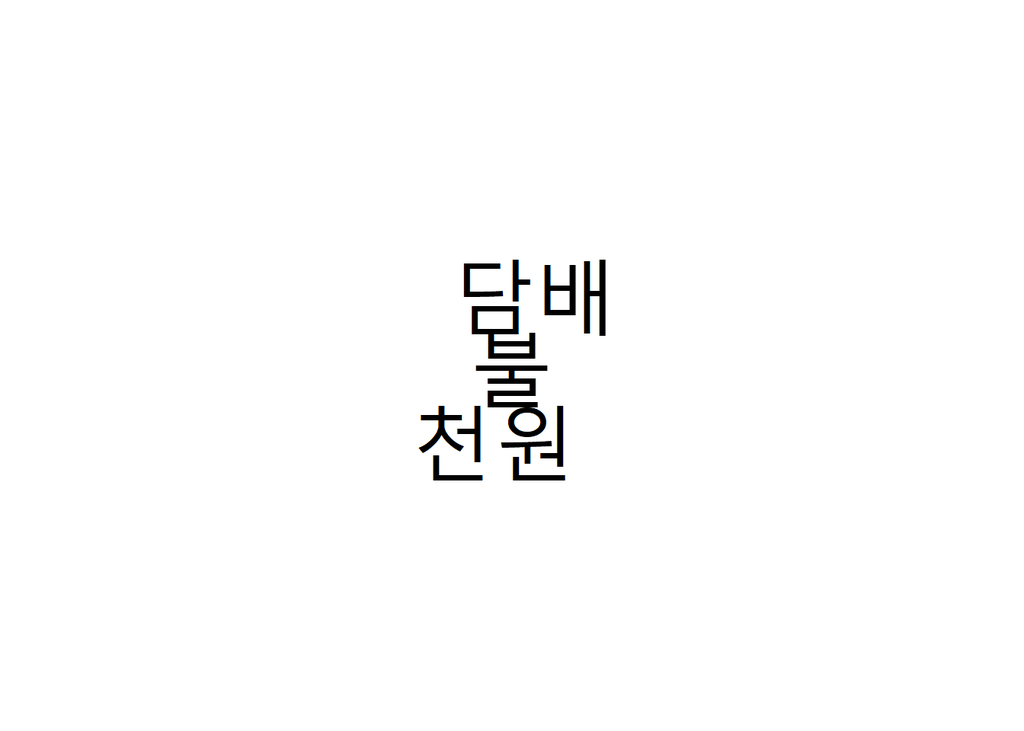

```r
wordcloud(names(data_wordcloud),data_wordcloud)
```

결과과 단순하게 나왔다. 일단 워드클라우드를 하기 위해 쓴 데이터가 적어서 결과값이 3개의 단어로 밖에 구성이 안되어있다.

“담배”, “불”, “천원”이 빈도수가 제일 많게 나와서 결과가 위와 같이 나온 것이다.

더 많은 데이터를 가지고 텍스트마이닝을 하면 더 정확한 분석이 될 것이다.

……………………………………………………………………………………………………………………………………………………………………………

```
연습문제

위의 data_all를 가지고 텍스트마이닝을 해볼것.
```